# Walkthrough: proporciones_encuesta_deportiva_v1.Rmd

## Estructura de Salida

### Líneas 664-690: Sección Question

```r
Question
========

`r articulo_contexto` `r contexto` realizó `r articulo_encuesta` `r termino_encuesta` a un grupo de sus `r poblacion_total_fmt` `r termino_usuarios` sobre la preferencia de su equipo favorito para ganar la `r competicion`. Para esto escogió al azar a `r tamano_muestra_fmt` `r termino_usuarios` y les preguntó sobre su equipo favorito para ganar dicha competición. Los resultados se muestran en la gráfica.

De acuerdo con los datos obtenidos en `r articulo_encuesta` `r termino_encuesta`, es correcto afirmar que

Answerlist
----------
- `r opciones_mezcladas[1]`
- `r opciones_mezcladas[2]`
- `r opciones_mezcladas[3]`
- `r opciones_mezcladas[4]`
```

**Características del enunciado**:

- **Contextualización completa**: Establece claramente el escenario de la encuesta
- **Distinción muestra-población**: Especifica tanto el total de usuarios como el tamaño de muestra
- **Integración de variables**: Usa todas las variables aleatorizadas para crear coherencia
- **Pregunta abierta**: “es correcto afirmar que” permite múltiples tipos de respuestas

### Líneas 691-746: Sección Solution

La sección de solución es extremadamente detallada y pedagógica:

#### Estructura paso a paso:

```r
### Paso 1: Identificar los datos conocidos
* `r articulo_contexto` `r contexto` tiene un total de `r poblacion_total_fmt` `r termino_usuarios`.
* Se realizó un(a) `r termino_encuesta` a una muestra de `r tamano_muestra_fmt` `r termino_usuarios` seleccionados al azar.
* Según el gráfico, `r valor_correcto_fmt` `r termino_usuarios` de la muestra prefieren al `r equipo_correcto`.

### Paso 2: Interpretar correctamente las proporciones
Los datos del gráfico representan únicamente la muestra de `r tamano_muestra_fmt` `r termino_usuarios`, no la población total de `r poblacion_total_fmt` `r termino_usuarios`.
```

#### Análisis detallado de distractores:

```r
**Análisis de distractores mejorados**:

- **Distractores con fracciones reducidas**: Opciones como "`r numerador_reducido_fmt` de cada `r denominador_reducido_fmt`" son matemáticamente equivalentes a la respuesta correcta (`r valor_correcto_fmt` de cada `r tamano_muestra_fmt`), pero pueden confundir a estudiantes que no reconocen la equivalencia de fracciones.

- **Distractores de confusión muestra-población**: Las opciones que mencionan proporciones sobre la población total de `r poblacion_total_fmt` `r termino_usuarios` son incorrectas, ya que `r articulo_encuesta` `r termino_encuesta` solo se realizó a `r tamano_muestra_fmt` personas.
```

#### Verificación matemática completa:

```r
### Paso 4: Verificación matemática
En la muestra de `r tamano_muestra_fmt` `r termino_usuarios`:

- `r equipo1`: `r valor1_fmt` `r termino_usuarios` (`r round(valor1/tamano_muestra*100, 1)`%)
- `r equipo2`: `r valor2_fmt` `r termino_usuarios` (`r round(valor2/tamano_muestra*100, 1)`%)
- `r equipo3`: `r valor3_fmt` `r termino_usuarios` (`r round(valor3/tamano_muestra*100, 1)`%)
- `r equipo4`: `r valor4_fmt` `r termino_usuarios` (`r round(valor4/tamano_muestra*100, 1)`%)
- `r equipo5`: `r valor5_fmt` `r termino_usuarios` (`r round(valor5/tamano_muestra*100, 1)`%)

Total: `r sum(c(valor1, valor2, valor3, valor4, valor5))` `r termino_usuarios` = `r tamano_muestra_fmt` `r termino_usuarios` (correcto)
```

#### Verificación de equivalencia de fracciones:

```r
### Paso 5: Verificación de equivalencia de fracciones (para distractores desafiantes)
Es importante reconocer que las fracciones pueden expresarse de diferentes formas equivalentes:

- **Fracción original**: `r valor_correcto_fmt` de cada `r tamano_muestra_fmt` = `r valor_correcto_fmt`/`r tamano_muestra_fmt`
- **Fracción reducida**: `r numerador_reducido_fmt` de cada `r denominador_reducido_fmt` = `r numerador_reducido_fmt`/`r denominador_reducido_fmt`

**Verificación matemática de equivalencia**:
`r valor_correcto_fmt`/`r tamano_muestra_fmt` = `r round(valor_correcto/tamano_muestra, 4)`
`r numerador_reducido_fmt`/`r denominador_reducido_fmt` = `r round(numerador_reducido/denominador_reducido, 4)`

Ambas fracciones son **matemáticamente equivalentes**, pero la fracción reducida puede ser más difícil de reconocer como correcta, lo que aumenta el desafío del problema.
```

### Líneas 747-761: Metainformación para r-exams

```r
Answerlist
----------
- `r if(solucion[1] == 1) "Verdadero" else "Falso"`
- `r if(solucion[2] == 1) "Verdadero" else "Falso"`
- `r if(solucion[3] == 1) "Verdadero" else "Falso"`
- `r if(solucion[4] == 1) "Verdadero" else "Falso"`

Meta-information
================
exname: proporciones_encuesta_deportiva
extype: schoice
exsolution: `r paste(as.integer(solucion), collapse="")`
exshuffle: TRUE
exsection: Estadística|Proporciones|Interpretación de gráficos|Muestreo
```

**Elementos clave de la metainformación**:

- **exname**: Identificador único del ejercicio
- **extype**: Tipo de pregunta (schoice = selección múltiple con única respuesta)
- **exsolution**: Vector binario que indica la respuesta correcta
- **exshuffle**: Permite mezclar las opciones automáticamente
- **exsection**: Categorización jerárquica para bancos de preguntas

## Resumen y Conclusiones

### Fortalezas del diseño

#### 1. **Aleatorización extrema**

- **15+ parámetros aleatorios**: Contextos, equipos, competiciones, valores, colores
- **Coherencia semántica**: Todas las combinaciones son realistas y coherentes
- **Variabilidad garantizada**: Mínimo 300 variantes distintas del problema

#### 3. **Distractores pedagógicamente sofisticados**

- **Errores conceptuales reales**: Basados en errores comunes de estudiantes
- **Fracciones equivalentes**: Aumentan el desafío matemático
- **Múltiples tipos de confusión**: Muestra-población, equipos incorrectos, generalizaciones indebidas

#### 4. **Validaciones robustas**

- **Integridad matemática**: Verificaciones en múltiples niveles
- **Calidad pedagógica**: Asegura valor educativo del ejercicio
- **Detección temprana de errores**: Mensajes específicos para debugging

#### 5. **Compatibilidad universal**

- **Múltiples formatos**: PDF, HTML, Word, Moodle
- **Gráficos de alta calidad**: Python/Matplotlib para visualizaciones profesionales
- **Adaptación automática**: Tamaños y formatos según el destino

```r
options(OutDec = ".")

# Código Python para generar el gráfico de barras horizontal
codigo_python <- paste0("
import matplotlib
matplotlib.use('Agg')
import matplotlib.pyplot as plt
import numpy as np

# Datos para el gráfico
equipos = ['", equipo1, "', '", equipo2, "', '", equipo3, "', '", equipo4, "', '", equipo5, "']
valores = [", valor1, ", ", valor2, ", ", valor3, ", ", valor4, ", ", valor5, "]
colores_grafico = ['", colores[1], "', '", colores[2], "', '", colores[3], "', '", colores[4], "', '", colores[5], "']

# Crear figura
fig, ax = plt.subplots(figsize=(8, 6))

# Crear gráfico de barras horizontal
y_pos = np.arange(len(equipos))
barras = ax.barh(y_pos, valores, color=colores_grafico, edgecolor='white', linewidth=1)

# Configurar etiquetas y título
ax.set_yticks(y_pos)
ax.set_yticklabels(equipos, fontsize=10, fontweight='bold')
ax.set_xlabel('Número de ", termino_usuarios, "', fontsize=12, fontweight='bold')
ax.set_title('Equipos favoritos para ganar la ", competicion, "', fontsize=14, fontweight='bold', pad=20)

# Añadir valores en las barras
for i, (barra, valor) in enumerate(zip(barras, valores)):
    width = barra.get_width()
    ax.text(width + 0.5, barra.get_y() + barra.get_height()/2,
            str(valor), ha='left', va='center', fontweight='bold', fontsize=10)

# Configurar límites del eje x
ax.set_xlim(0, max(valores) + 5)

# Añadir grilla sutil
ax.grid(axis='x', alpha=0.3, linestyle='--')
ax.set_axisbelow(True)

# Ajustar diseño
plt.tight_layout()

# Guardar en múltiples formatos
plt.savefig('grafico_barras.png', dpi=150, bbox_inches='tight',
           transparent=True, format='png')
plt.savefig('grafico_barras.pdf', dpi=150, bbox_inches='tight',
           transparent=True, format='pdf')
plt.close()
")

# Ejecutar código Python
py_run_string(codigo_python)
```

# Question

Una plataforma de streaming realizó la consulta a un grupo de sus 40000 aficionados sobre la preferencia de su equipo favorito para ganar la Liga Europa. Para esto escogió al azar a 150 aficionados y les preguntó sobre su equipo favorito para ganar dicha competición. Los resultados se muestran en la gráfica.

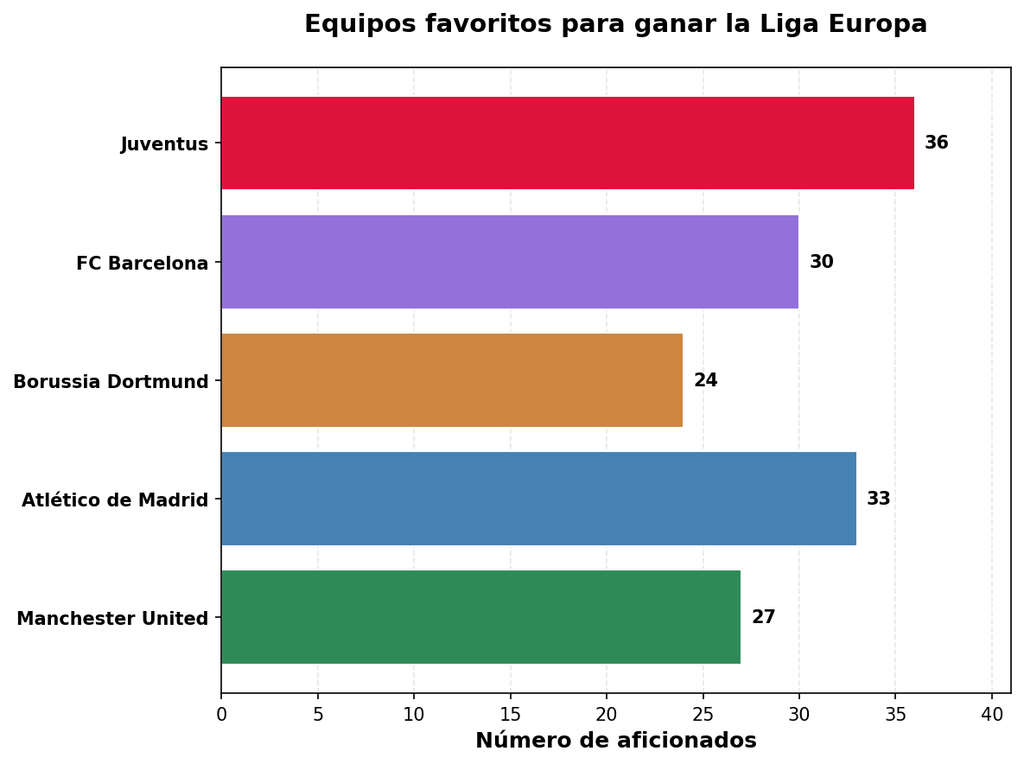

De acuerdo con los datos obtenidos en la consulta, es correcto afirmar que

## Answerlist

- alrededor de 30 de cada 150 aficionados del plataforma de streaming da por favorito al FC Barcelona.
- sólo 150 de los 40000 aficionados del plataforma de streaming tienen preferencia por un equipo para ganar la Liga Europa.
- alrededor de 30 de cada 40000 aficionados del plataforma de streaming da por favorito al FC Barcelona.
- ninguno de los 40000 aficionados del plataforma de streaming da por favorito al Liverpool.

### Innovaciones técnicas

#### 1. **Función `generar_valores_coherentes()`**

- **Algoritmo en dos fases**: Distribución escalonada + aleatoria
- **Ajuste inteligente**: Garantiza suma exacta manteniendo rangos válidos
- **Método de emergencia**: Fallback robusto para casos extremos

#### 2. **Sistema de distractores por tipos**

- **Categorización inteligente**: 3 tipos diferentes de distractores
- **Selección garantizada**: Un distractor de cada tipo para máxima diversidad
- **Fallbacks múltiples**: Métodos de respaldo para casos extremos

#### 3. **Integración Python-R**

- **Reticulate avanzado**: Generación de código Python dinámico
- **Gráficos profesionales**: Matplotlib con personalización completa
- **Compatibilidad universal**: Funciona en todos los formatos de salida

### Aplicaciones pedagógicas

#### 1. **Evaluación auténtica**

- **Comprensión real**: No permite atajos o patrones
- **Pensamiento crítico**: Requiere análisis matemático genuino
- **Transferencia de conocimiento**: Aplicable a situaciones reales

#### 2. **Feedback educativo**

- **Explicaciones detalladas**: Solución paso a paso
- **Análisis de errores**: Explicación de por qué cada distractor es incorrecto
- **Verificación matemática**: Demostración completa de la solución

#### 3. **Adaptabilidad curricular**

- **Múltiples niveles**: Ajustable para diferentes grados de dificultad
- **Contextos diversos**: Fácil modificar para diferentes temas
- **Escalabilidad**: Estructura reutilizable para otros tipos de problemas

### Recomendaciones para uso

#### 1. **Implementación en aula**

- **Banco de preguntas**: Generar múltiples versiones para exámenes
- **Práctica individual**: Ejercicios únicos para cada estudiante
- **Evaluación formativa**: Feedback inmediato con explicaciones detalladas

#### 2. **Desarrollo futuro**

- **Extensión a otros temas**: Adaptar la estructura para geometría, álgebra, etc.
- **Niveles de dificultad**: Implementar parámetros de complejidad ajustables
- **Análisis de respuestas**: Integrar con sistemas de learning analytics

#### 3. **Mantenimiento**

- **Actualización de datos**: Equipos y competiciones actuales
- **Validación continua**: Verificar que las validaciones siguen siendo efectivas
- **Optimización**: Mejorar algoritmos basado en uso real

Este ejercicio representa un ejemplo de excelencia en el diseño de evaluaciones automatizadas, combinando rigor matemático, sofisticación técnica y valor pedagógico en una solución integral y escalable.

Una plataforma de streaming tiene un total de 40000 aficionados.

Se realizó un(a) consulta a una muestra de 150 aficionados seleccionados al azar.

Según el gráfico, 30 aficionados de la muestra prefieren al FC Barcelona.

### Paso 2: Interpretar correctamente las proporciones

Los datos del gráfico representan únicamente la muestra de 150 aficionados, no la población total de 40000 aficionados.

### Paso 3: Analizar cada opción

**Opción correcta**: “alrededor de 30 de cada 150 aficionados del plataforma de streaming da por favorito al FC Barcelona.” Esta opción es correcta porque interpreta adecuadamente que 30 de cada 150 aficionados **de la muestra** prefieren al FC Barcelona. Esto representa una proporción del 20% en la muestra.

**Análisis de distractores**:

- Las opciones que mencionan proporciones sobre la población total de 40000 aficionados son incorrectas, ya que la consulta solo se realizó a 150 personas.
- Las opciones que afirman que “ninguno” prefiere cierto equipo son incorrectas porque no podemos hacer esa generalización a partir de una muestra.
- Las opciones que confunden el tamaño de la muestra con las preferencias totales malinterpretan los datos.

### Paso 4: Verificación matemática

En la muestra de 150 aficionados:

- Manchester United: 27 aficionados (18%)
- Atlético de Madrid: 33 aficionados (22%)
- Borussia Dortmund: 24 aficionados (16%)
- FC Barcelona: 30 aficionados (20%)
- Juventus: 36 aficionados (24%)

Total: 150 aficionados = 150 aficionados ✓

### Conclusión

La respuesta correcta interpreta adecuadamente que los datos del gráfico se refieren a la muestra de 150 aficionados, no a la población total.

## Answerlist

- Verdadero
- Falso
- Falso
- Falso

# Meta-information

exname: proporciones_encuesta_deportiva extype: schoice exsolution: 1000 exshuffle: TRUE exsection: Estadística|Proporciones|Interpretación de gráficos|Muestreo